# SSA

Волканова Маргарита

4 апреля 2019 г

# 1 Классическое сезонное разложение временного ряда

# 2 Модельные ряды

Модельные данные использую 2 и 8.

```r
library(stats)
library(Rssa)
data <-read.csv('D:/Dokumy/Desktop/Golyandina/stud.txt', sep="\t", header=TRUE)
series_short<- data[1:100, 'COL8']
series_long <- data[, 'COL2']
```

## 2.1 Длинный ряд

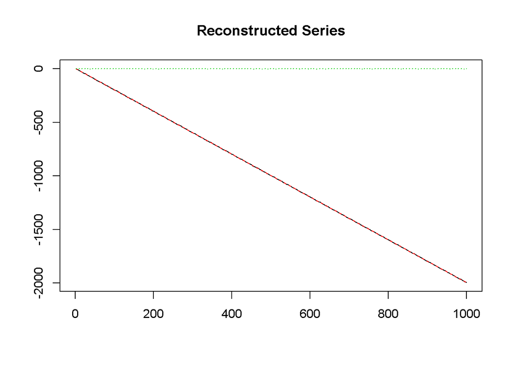

```r
s <-ssa(series_long, column.projector = "centering", row.projector = "centering")
plot(reconstruct(s, groups = list(trend = seq_len(nspecial(s)))))
```

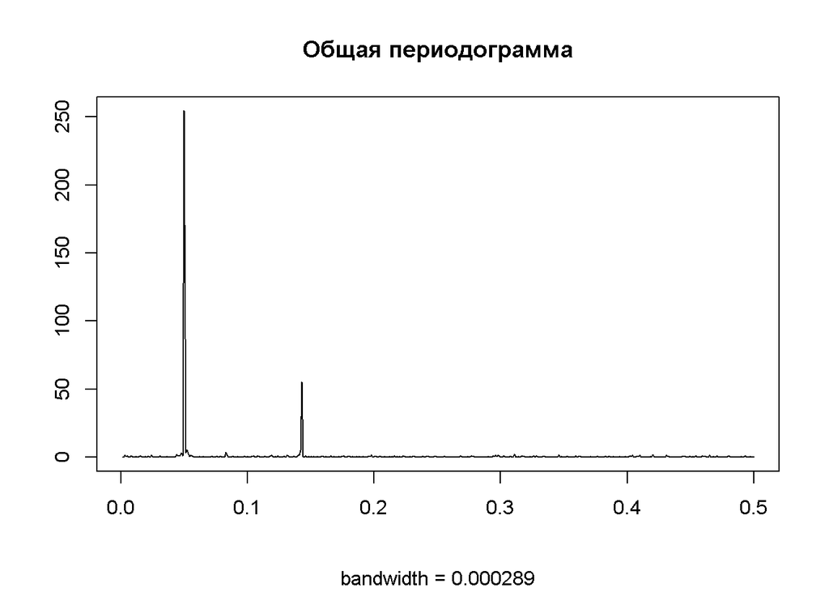

```r
spec.pgram(series_long ,log="no",detrend=TRUE,fast =FALSE,main="Общая периодограмма",ann="False")
```

Видим, что первые два числа не имеют пар, поэтому предпологаем, что они относятся к тренду. Потом наблюдаем 3 ступеньки - 3 пары соб. чисел (3-4,5-6,7-8). Так как изначально период нам не известен, то берем L=N/2.

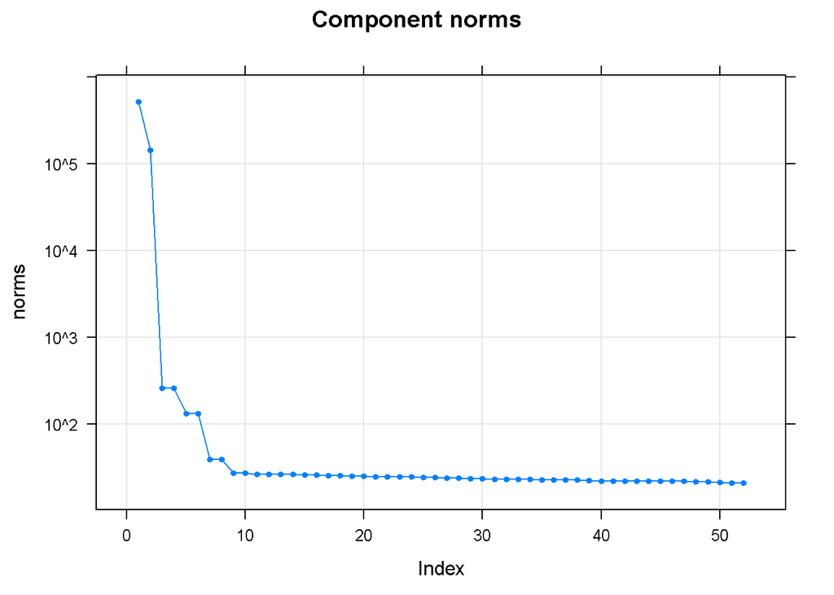

```r
plot(s, L=500)
```

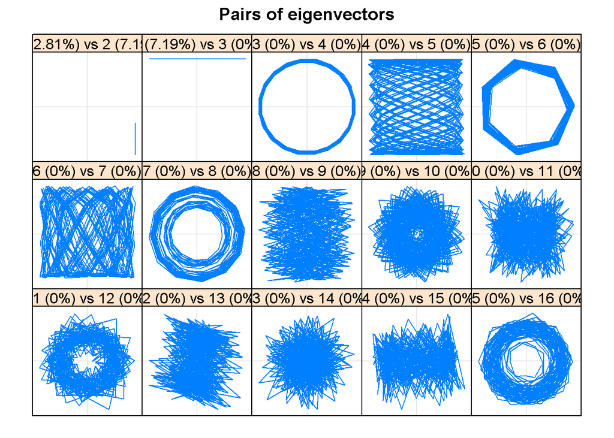

```r
plot(s,  type = "paired", idx = 1:15)
```

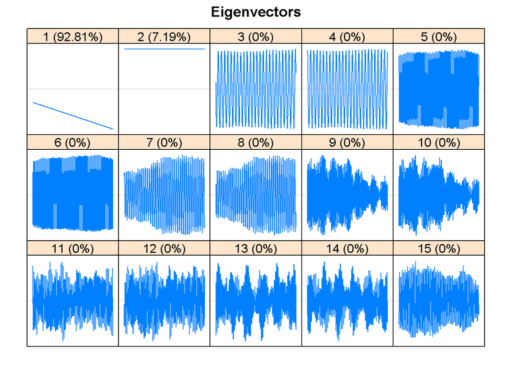

```r
plot(s, type = "vectors", idx = 1:15)
```

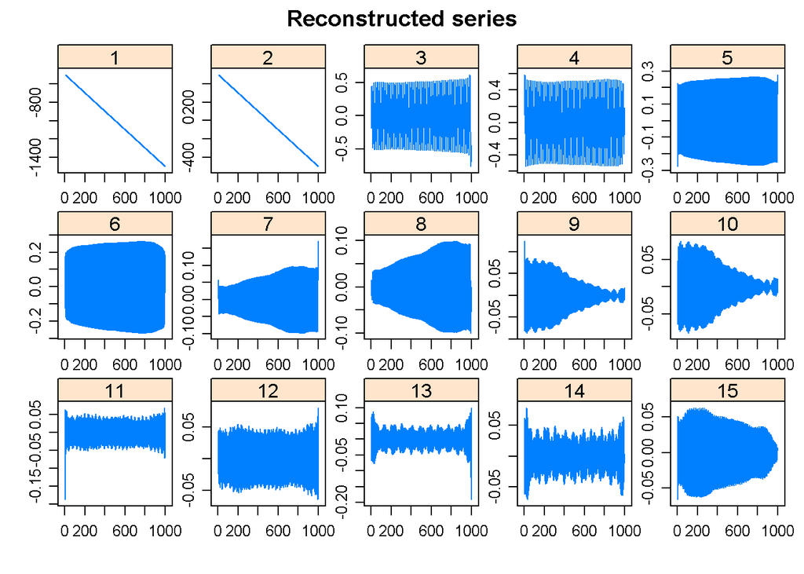

```r
plot(s, type = "series", groups = as.list(1:15))
```

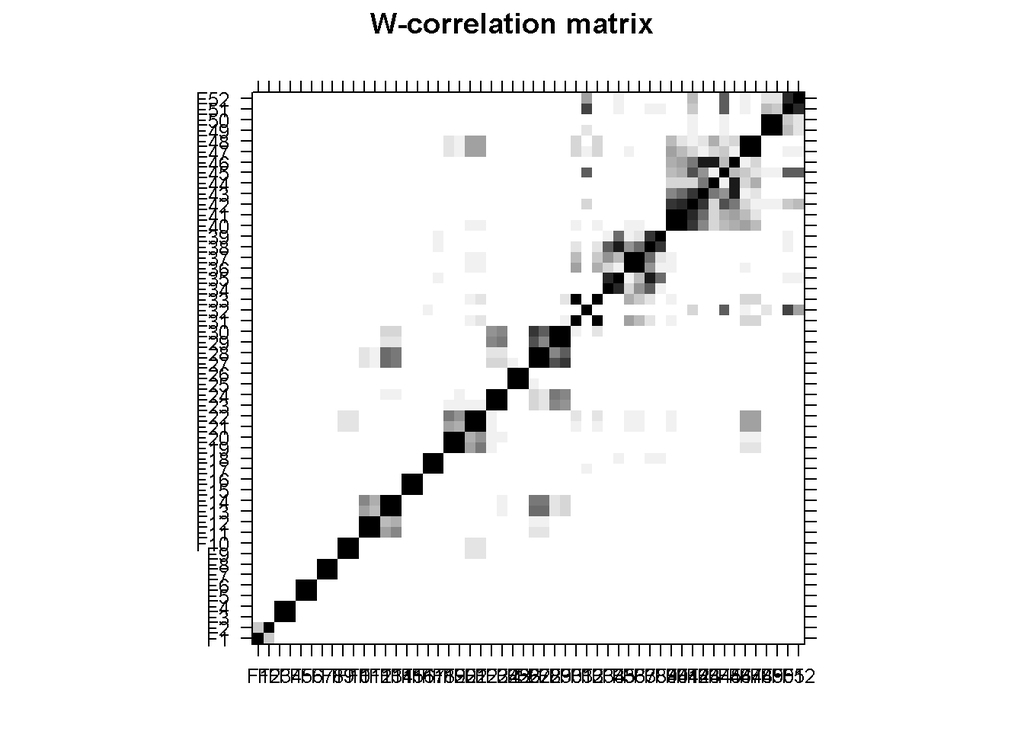

```r
plot(wcor(s))
```

```r
#Давайте посомтрим периоды.
pe <- parestimate(s, groups = list(c(3, 4,5,6,7,8)), method = "esprit")
pe
```

```
##    period     rate   |    Mod     Arg  |     Re        Im
##    12.016   0.000578 |  1.00058   0.52 |  0.86688   0.49967
##   -12.016   0.000578 |  1.00058  -0.52 |  0.86688  -0.49967
##     6.998   0.000103 |  1.00010   0.90 |  0.62331   0.78211
##    -6.998   0.000103 |  1.00010  -0.90 |  0.62331  -0.78211
##    19.991   0.000065 |  1.00006   0.31 |  0.95107   0.30918
##   -19.991   0.000065 |  1.00006  -0.31 |  0.95107  -0.30918
```

Выделим тренд и сезонность и посмотрим на шум

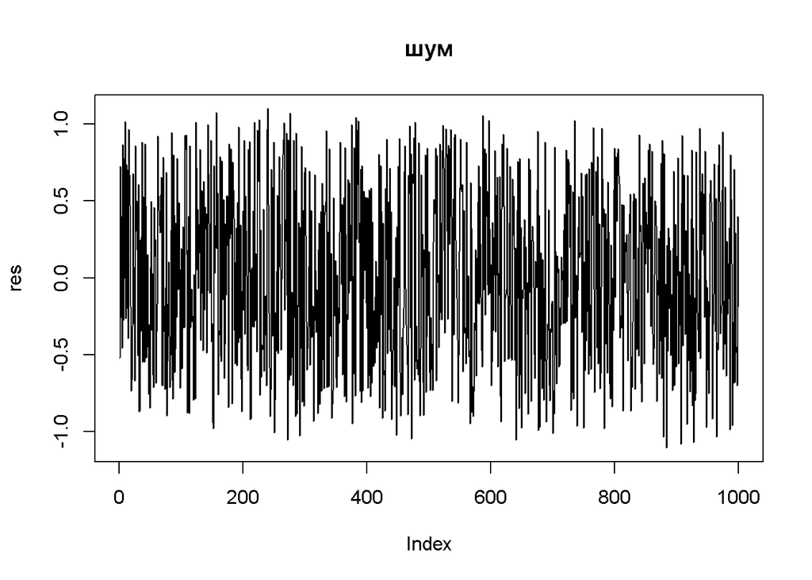

```r
#медленно меняющиеся 1,2
library(normwhn.test)
r <- reconstruct(s, groups = list(Trend = c(1, 2), Season1 = c(3,4), Season2 = c(5, 6),Season3 = c(7, 8)))
res<-residuals(r)
plot(res, main="шум",type="l")
```

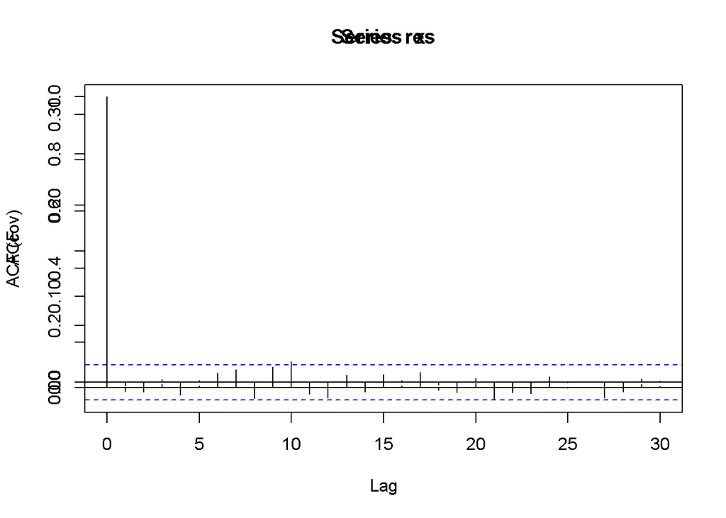

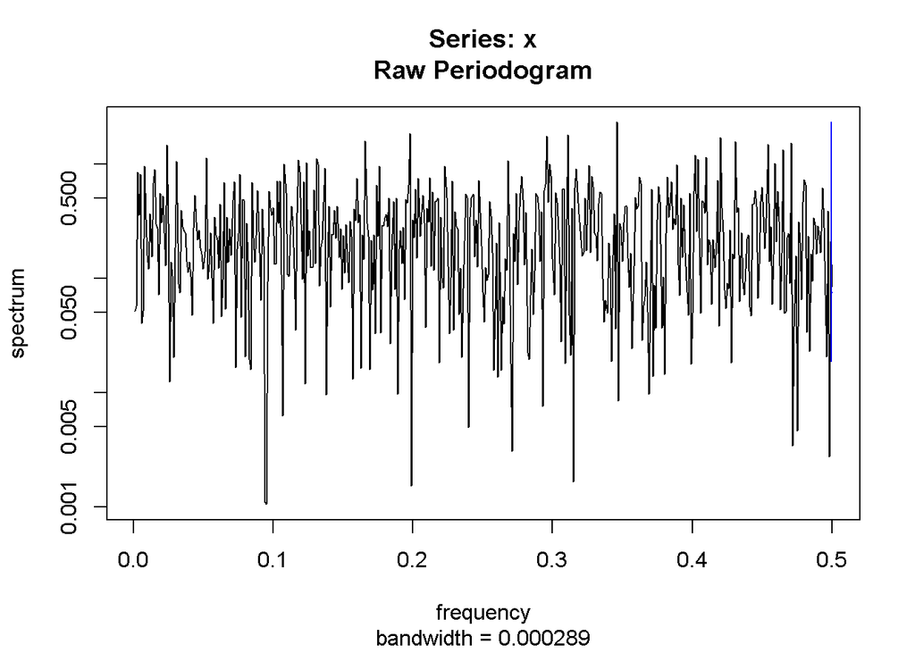

```
## [1] "no. of observations"
## [1] 1000
## [1] "T"
## [1] 500
## [1] "CVM stat MN"
## [1] 1.041792
## [1] "tMN"
## [1] 0.9344912
## [1] "test value"
## [1] 0.6403242
```

```r
acf(res)
 par(new=TRUE)
whitenoise.test(res)
```

По автокорреляции видно, что он является белым.

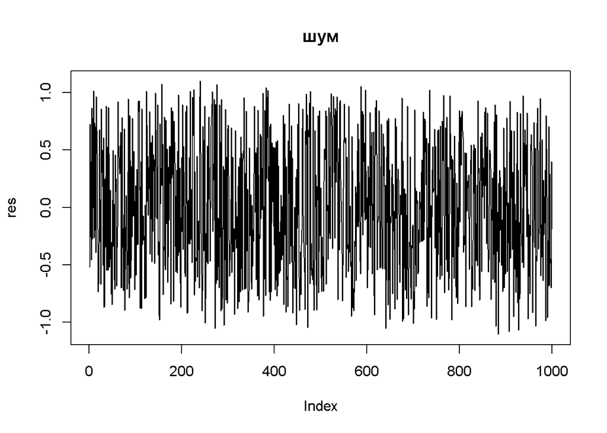

```r
#медленно меняющиеся 1,2
r <- reconstruct(s, groups = list(Trend = c(1, 2), Season1 = c(3,4), Season2 = c(5, 6),Season3 = c(7, 8)))
res<-residuals(r)
plot(res, main="шум",type="l")
```

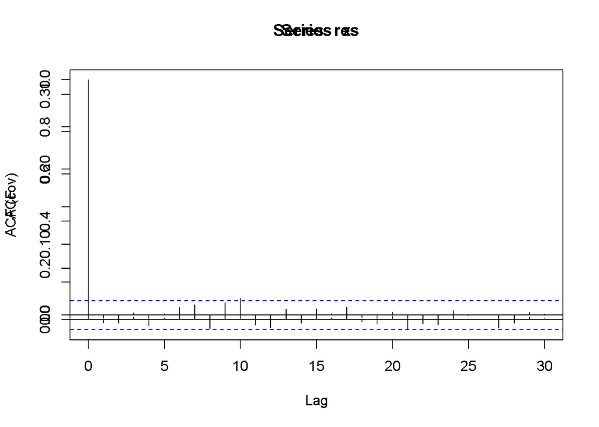

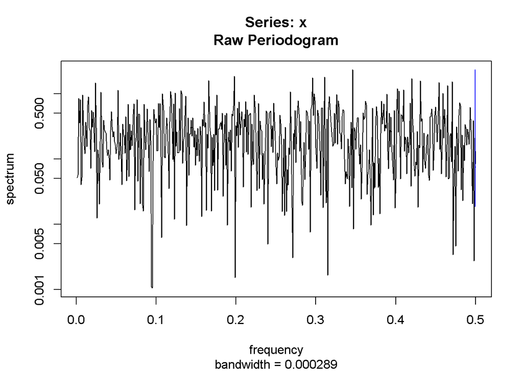

```
## [1] "no. of observations"
## [1] 1000
## [1] "T"
## [1] 500
## [1] "CVM stat MN"
## [1] 1.041792
## [1] "tMN"
## [1] 0.9344912
## [1] "test value"
## [1] 0.6403242
```

```r
acf(res)
 par(new=TRUE)
whitenoise.test(res)
```

```r
#С тремя компонентами сезонности шум является белым.
```

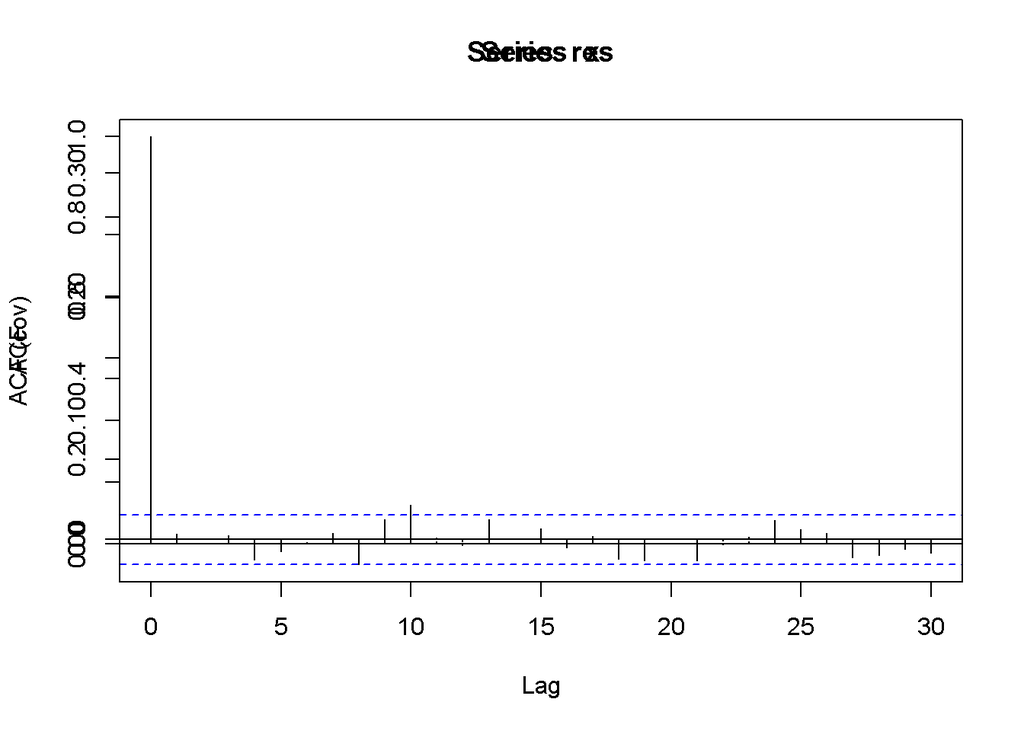

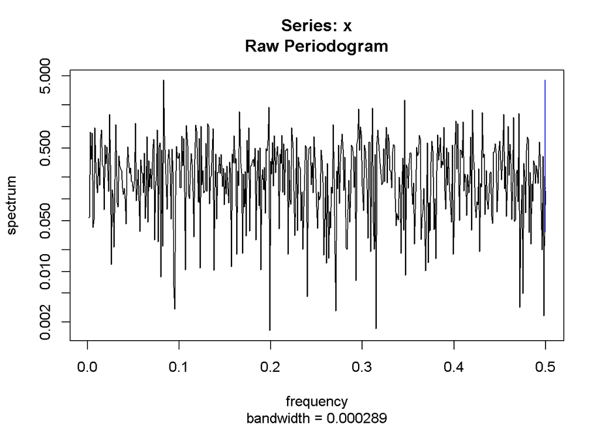

```
## [1] "no. of observations"
## [1] 1000
## [1] "T"
## [1] 500
## [1] "CVM stat MN"
## [1] 1.284925
## [1] "tMN"
## [1] 6.371127
## [1] "test value"
## [1] 0.001444725
```

```r
r <- reconstruct(s, groups = list(Trend = c(1, 2), Season1 = c(3,4), Season2 = c(5, 6)))
res<-residuals(r)
acf(res)
 par(new=TRUE)
whitenoise.test(res)
```

```r
#test value=0.001444725<0.01 - нулевая гипотеза отклоняется, шум не является белым. Значит используем все три компоненты сезонности.
```

## 2.2 Короткий ряд

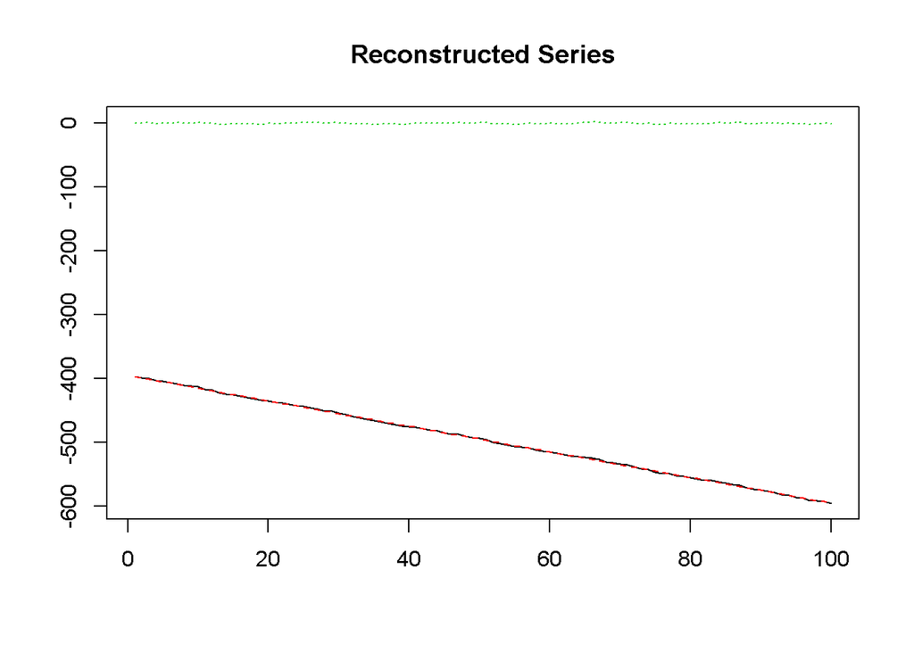

```r
s <-ssa(series_short, column.projector = "centering", row.projector = "centering")
plot(reconstruct(s, groups = list(trend = seq_len(nspecial(s)))))
```

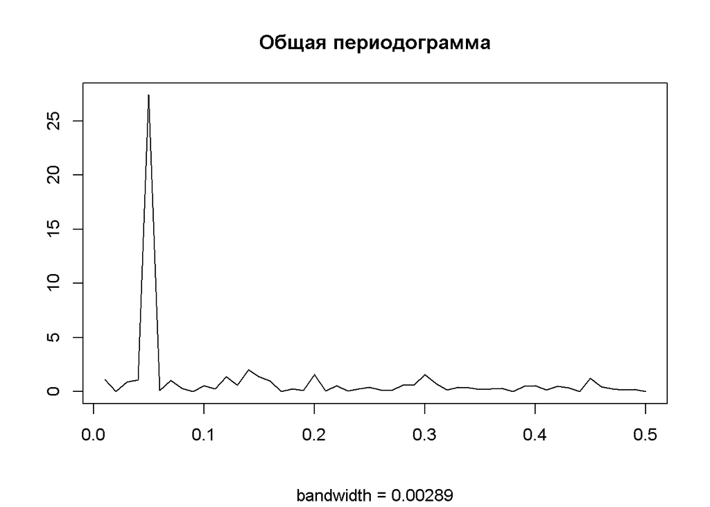

```r
spec.pgram(series_short ,log="no",detrend=TRUE,fast =FALSE,main="Общая периодограмма",ann="False")
```

Аналогично, первые два соб. числа скорее всего относятся к тренду. Дальше у нас есть ступенечка и можем предпоожить что есть еще одна ступенька, которая потом сливается с шумом.

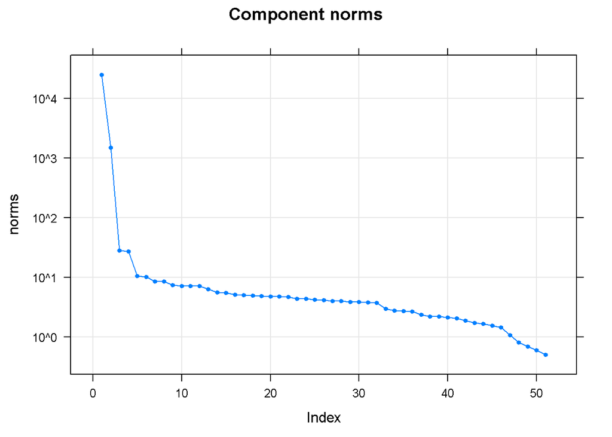

```r
plot(s,L=50)
```

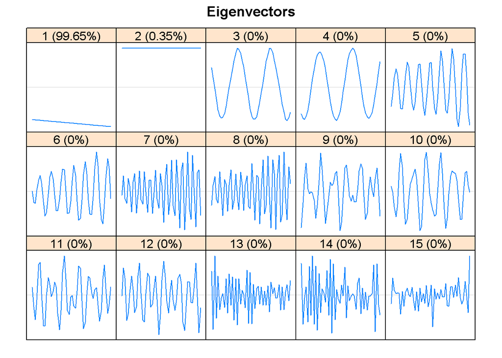

```r
plot(s, type = "vectors", idx = 1:15)
```

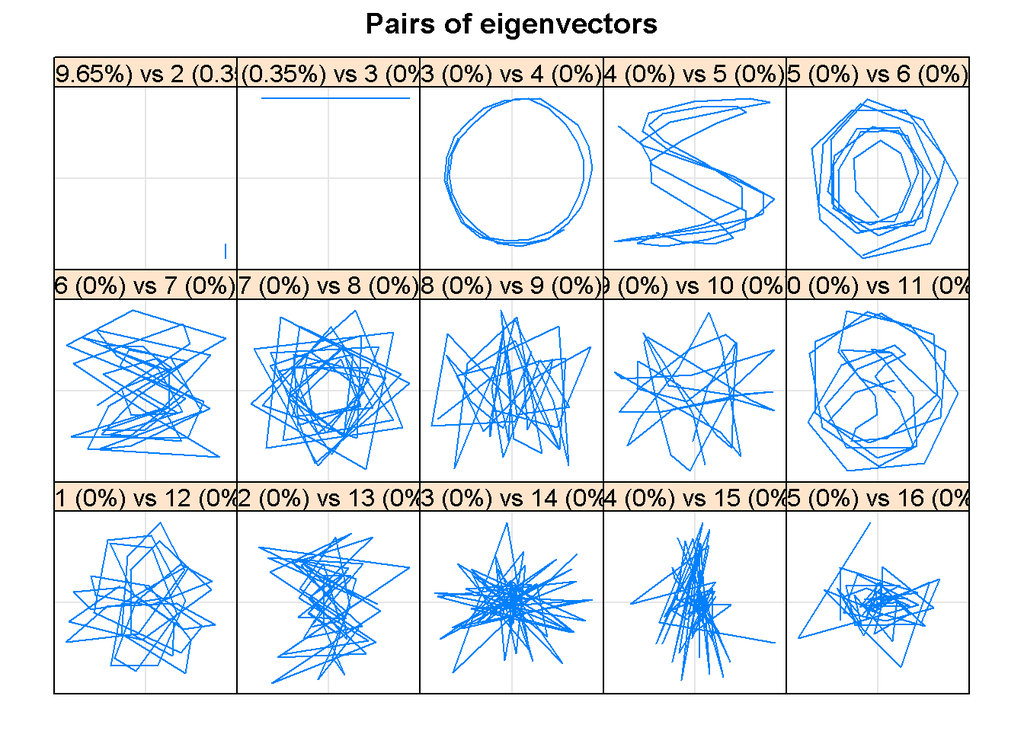

```r
plot(s,  type = "paired", idx = 1:15)
```

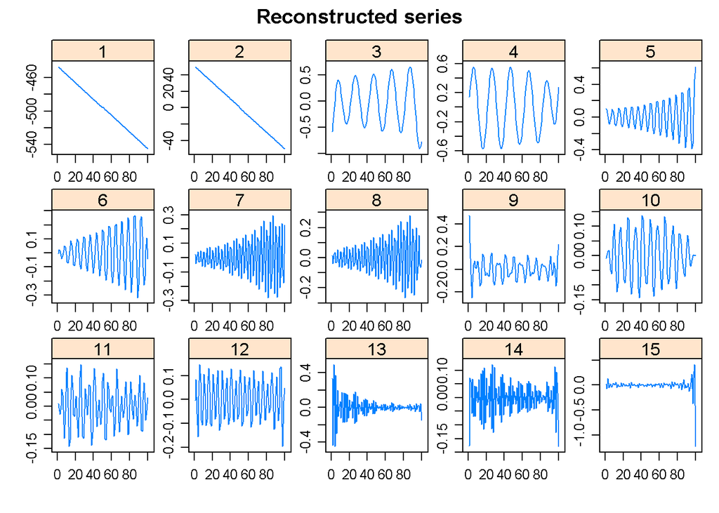

```r
plot(s, type = "series", groups = as.list(1:15))
```

```r
#Давайте посомтрим периоды.
pe <- parestimate(s, groups = list(c(3, 4,5,6,7,8)), method = "esprit")
pe
```

```
##    period     rate   |    Mod     Arg  |     Re        Im
##     7.039   0.007639 |  1.00767   0.89 |  0.63214   0.78473
##    -7.039   0.007639 |  1.00767  -0.89 |  0.63214  -0.78473
##    20.148  -0.000053 |  0.99995   0.31 |  0.95172   0.30680
##   -20.148  -0.000053 |  0.99995  -0.31 |  0.95172  -0.30680
##     3.319  -0.000661 |  0.99934   1.89 | -0.31655   0.94788
##    -3.319  -0.000661 |  0.99934  -1.89 | -0.31655  -0.94788
```

Выделим тренд и сезонность и посмотрим на шум. Проверим является ли он белый с Тремя сезонностями:

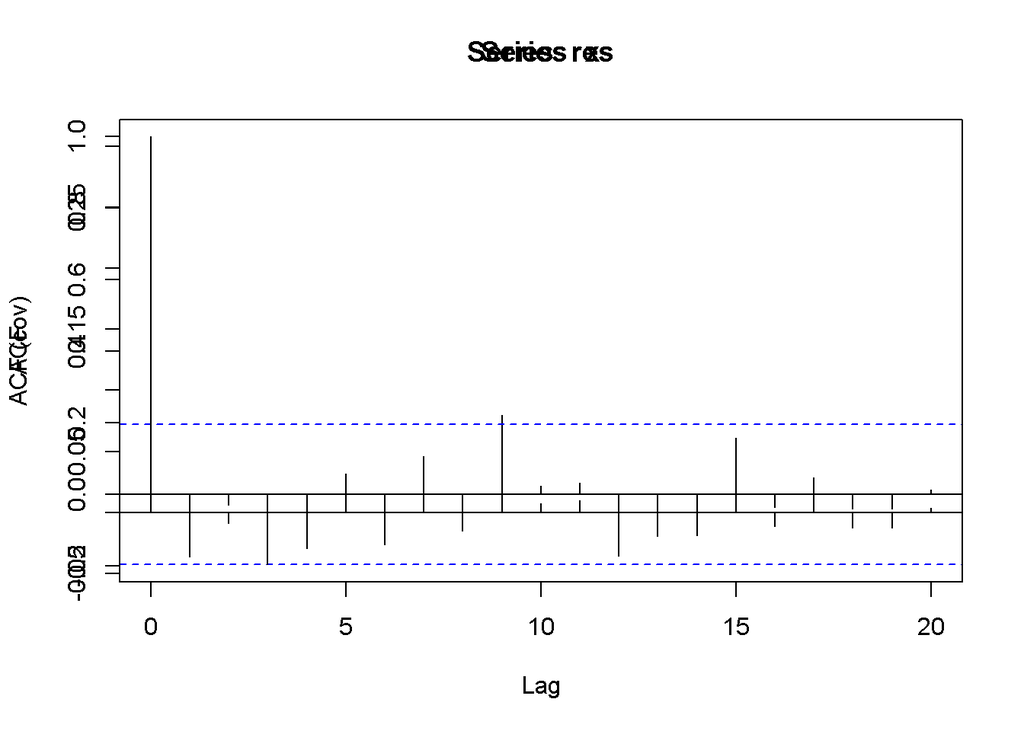

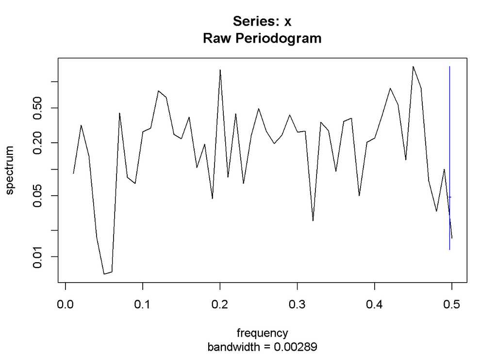

```
## [1] "no. of observations"
## [1] 100
## [1] "T"
## [1] 50
## [1] "CVM stat MN"
## [1] 1.018863
## [1] "tMN"
## [1] 0.1333824
## [1] "test value"
## [1] 0.9468276
```

```r
#для 2х компонент
#медленно меняющиеся 1,2 - тренд. Сначала рассмотрим с двумя синусами, потом с тремя.
library(normwhn.test)
r <- reconstruct(s, groups = list(Trend = c(1, 2), Season1 = c(3,4), Season2 = c(5, 6),Season3 = c(7, 8)))
res<-residuals(r)
#plot(res, main="шум",type="l")
acf(res)
 par(new=TRUE)
whitenoise.test(res)
```

```r
#является ли шум белым?
#"no. of observations" - длина ряда
#T - длина используемой периодограммы - период?
#CVM stat MN" ?статистика Мизеса
#tMN-статистика
#test value - p value
#Вычисляется статистика типа фон Мизеса, которая оценивается по распределению N(0,4). Таким образом, статистика конечных выборок легко генерируется.
```

test value =0.9468276, то есть шум является белым.  
Давайте посомтрим, можем ли мы уменьшесть количество компонент сезонности. Рассмотрим разложение с одной компонентой сезонности.

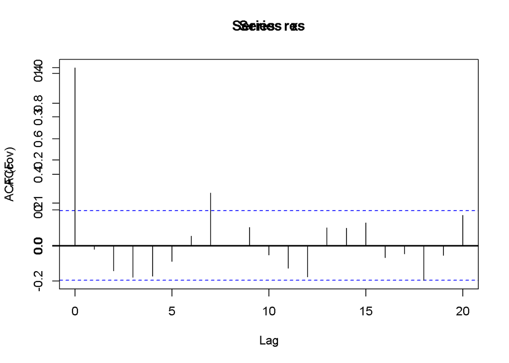

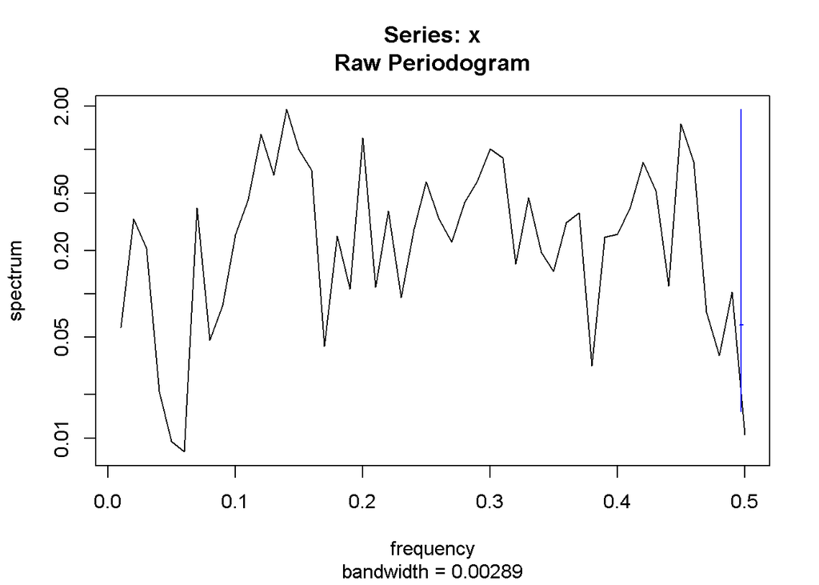

```
## [1] "no. of observations"
## [1] 100
## [1] "T"
## [1] 50
## [1] "CVM stat MN"
## [1] 1.012677
## [1] "tMN"
## [1] 0.08963655
## [1] "test value"
## [1] 0.9642522
```

```r
r <- reconstruct(s, groups = list(Trend = c(1, 2), Season1 = c(3,4)))
res<-residuals(r)
#plot(res, main="шум",type="l")
acf(res)
 par(new=TRUE)
whitenoise.test(res)
```

Шум все еще является белым. (test value=0.9642522)  
Теперь рассмотрим остаток без тренда.

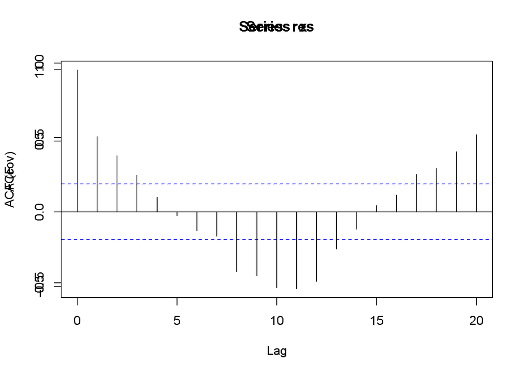

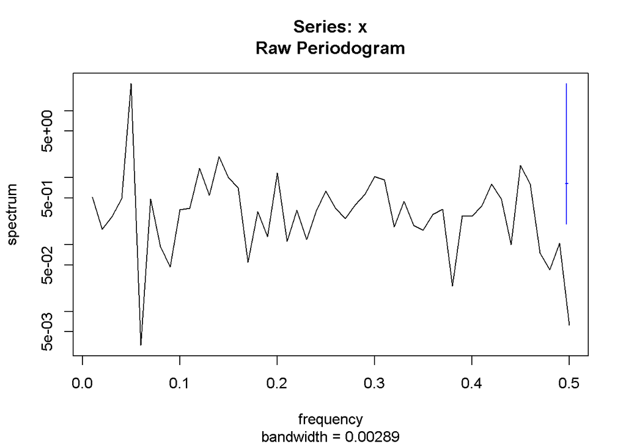

```
## [1] "no. of observations"
## [1] 100
## [1] "T"
## [1] 50
## [1] "CVM stat MN"
## [1] 13.54178
## [1] "tMN"
## [1] 88.68376
## [1] "test value"
## [1] 0
```

```r
r <- reconstruct(s, groups = list(Trend = c(1, 2)))
res<-residuals(r)
#plot(res, main="шум",type="l")
acf(res)
 par(new=TRUE)
whitenoise.test(res)
```

Заметим,что данный остаток уже не является белым. Это видно и по автокорреляции (она периодична) и по тесту (test value=0). Значит достаточно использовать одну компоненту сезонности.

# 3 Реальный ряд

Данные: Ежемесячные продажи австралийского Крепленого вина в тысячах литров с января 1980 года по июль 1995 года. Виноделами в бутылках объемом не более 1 литра. Многомерный временной ряд с 187 наблюдениями

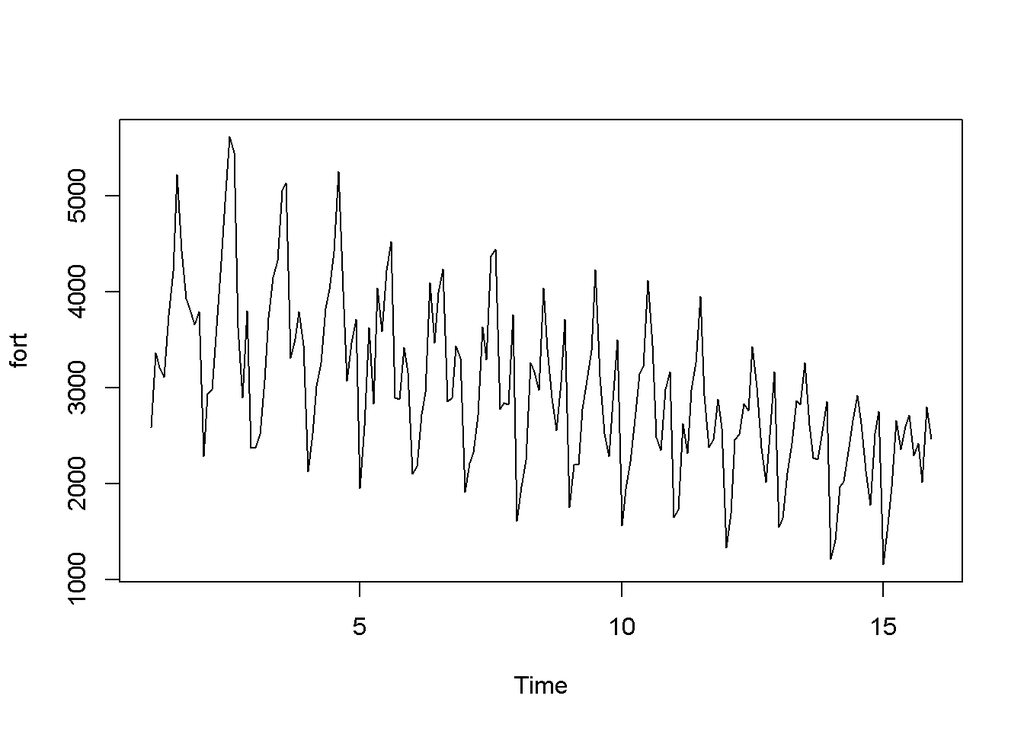

```r
data("AustralianWine")
wine <- window(AustralianWine, end = time(AustralianWine)[180])

fort <- ts(wine[, "Fortified"],frequency = 12)
plot(fort)
```

Тренд убывает,отдаленно напоминает линейный, но явно есть отклонения от него. Предполагаю, что модель мультипликативная, так как амплитуда колебаний ведет себя пропорционально тренду и шум пропорционален всему сигналу.

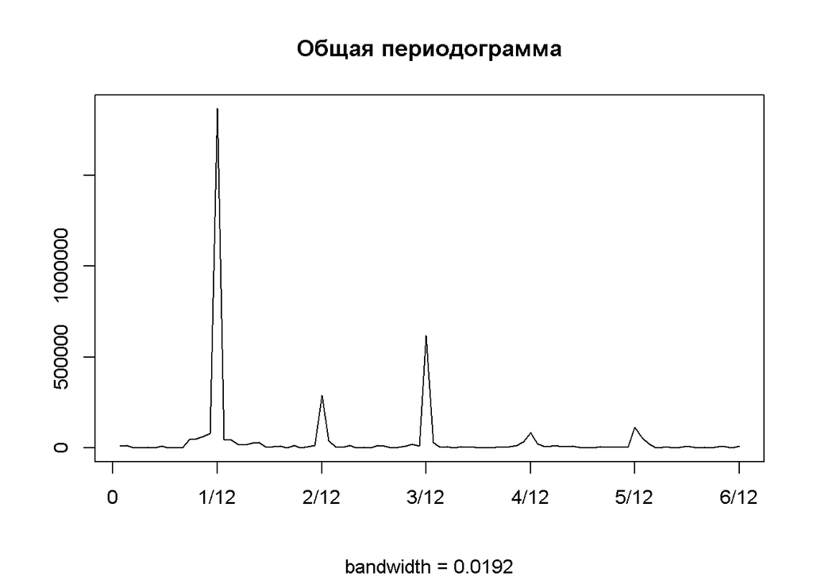

```r
spec.pgram(fort,log="no",detrend=TRUE,xaxt='n',fast =FALSE,main="Общая периодограмма",ann="False")
axis(1, at = c(0,1,2,3,4,5,6), labels = c('0', '1/12', '2/12', '3/12', '4/12', '5/12', '6/12'))
```

На периодограммы можно видим пики, значит есть сезонные компоненты с частотами 1/12, 2/12, 3/12, 4/12, 5/12. Заметим, что частоты 6/12 нет, значит ряды, восстановленные по одной компоненте смотреть не надо - “пилы” нет.

Мультипликативная модель имеет вид:
$$X_n=T_n(1+C_n)(1+\epsilon_n).$$

### 3.0.1 Аддитивная модель (шаги)

$$X_n=T_n+C_n+S_n+N_t=TC_t+S_t+N_t$$
где $T_n$ - тренд, $TC_t$ - амплитуда колебаний ведет себя пропорционально тренду, $S_t$ - сезонность (с перодом p), $N_t$ - шум.
Будем говорить про аддитивную модель, но если будет мултипликативная, то просто берем log от ряда и дальше рассматриваем как аддитивную.
Алгоритм разложения:
1.Скользящее среднее с периодом p. Получаем $\hat{T_t}$
2. $X_t-\hat{T_t}$, получаем $\hat{S_t+N_t}$
3.Далее рассматриваем среднее арифметическое “всех январей, февралей, мартов и т.д.”, то есть усредняем
$$\hat{S_t+N_t} \text{по периоду} P$$
Получаем оценку сезонности $\hat{S_t}$
4.$X_t - \hat{S_t}$, получаем $\hat{T_t+N_t}$
5.Применяем фильтр с небольшой шириной окна к $\hat{T_t+N_t}$ и получаем $\overline{T_t}$.
(Скользящее среднее с окном бартлетта длинной 5.)
6.$\hat{N_t}=\hat{T_t+N_t}-\overline{T_t}$
$$X_t=\overline{T_t}+\hat{S_t}+\hat{N_t}$$

Воспользуемся функцией decompose, которая раскладывает ряд на сумму трех компонент: тренд, шум и сезонность.

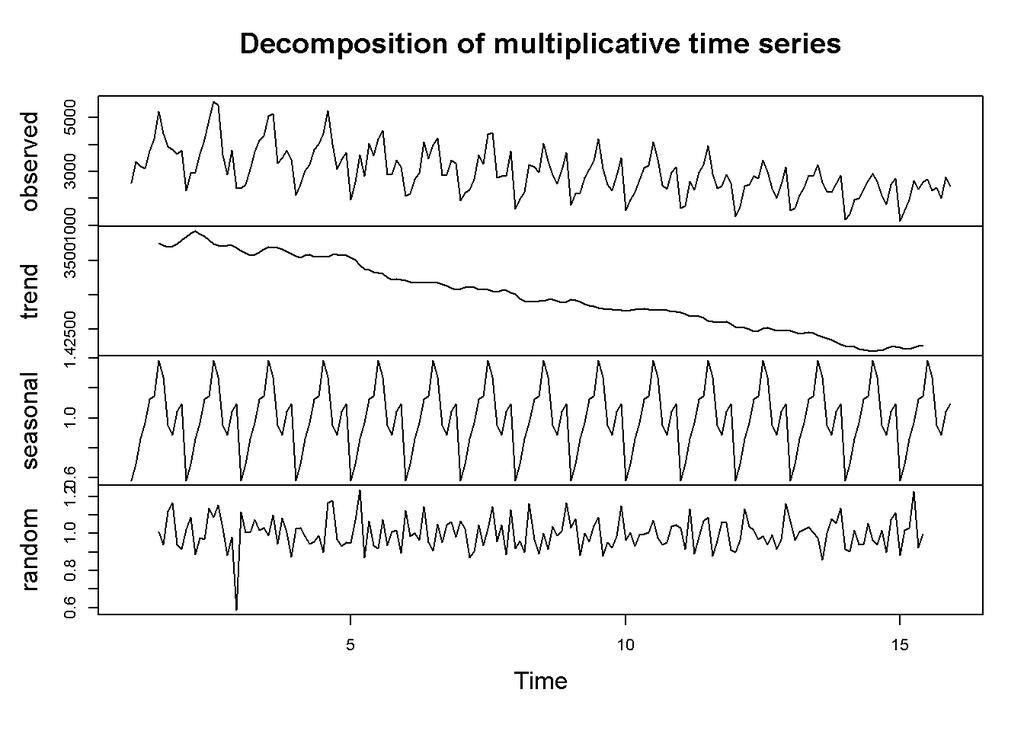

```r
fort_d<-stats::decompose(fort,type="multiplicative",filter=NULL)
plot(fort_d)
```

Нарисум тренд на фоне ряда. Тренд достаточно резкий, хотелось бы чтобы был более гладкий.

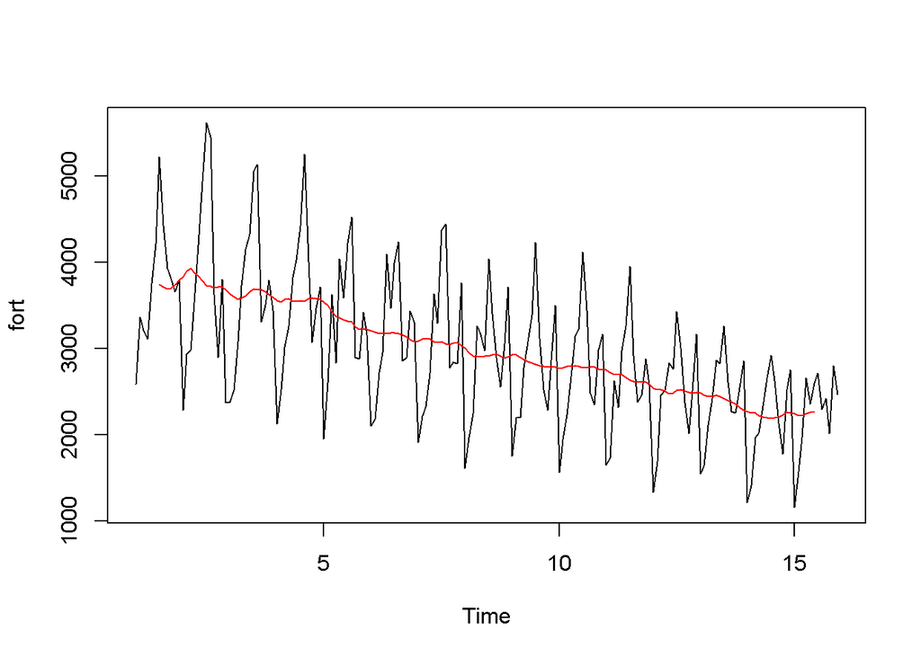

```r
plot(fort)
lines(fort_d$trend,col="red")
```

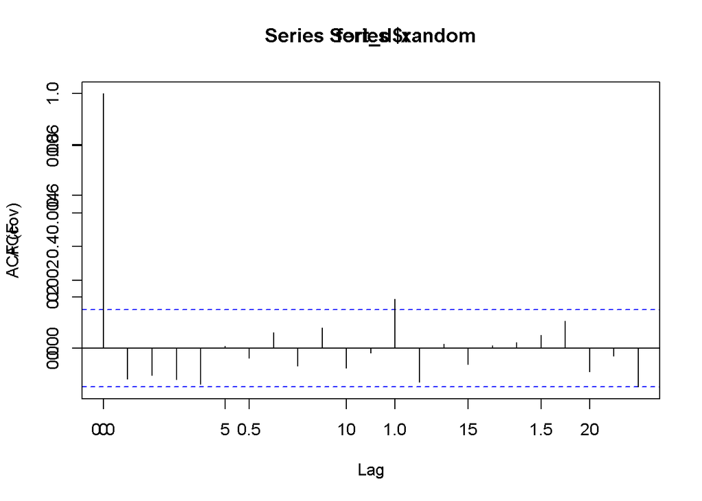

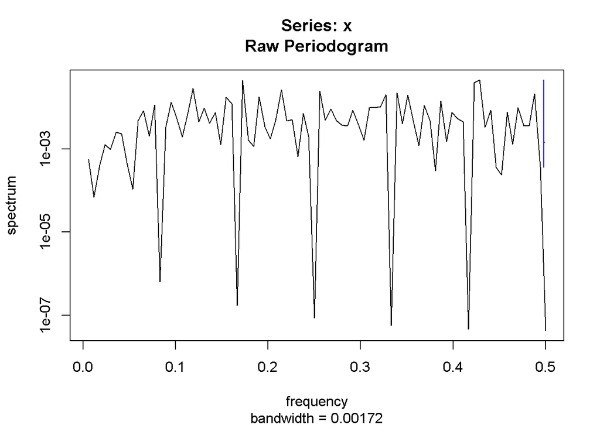

```
## [1] "no. of observations"
## [1] 168
## [1] "T"
## [1] 84
## [1] "CVM stat MN"
## [1] 1.584971
## [1] "tMN"
## [1] 5.36135
## [1] "test value"
## [1] 0.007347387
```

```r
#Рассмотрим автокорреляцию остатков
acf(fort_d$random, na.action = na.omit)
 par(new=TRUE)
whitenoise.test(na.omit(ts(fort_d$random)))
```

## 3.1 STL (seasonal trend decomposition with LOESS)

Это процедура декомпозиции временного ряда на сезонную, трендовую составляющие и остатки, которая использует метод локальных регрессий (LOESS).  
Применима только для аддитивной модели. Так как у нас мультипликативная, то стоило бы прологарифмировать ряд, но в данной ситуации у нас локально сглаживание, поэтому можно использовать для любого поведения амплитуды.

```r
#fort_log<-log(fort)
```

(Усовершенствование предыдущего алгоритма) Рассмотрим функцию stl:  
Внутренний цикл STL:  
1. Вычесть тренд $Y_t=X_t-T^{(k)}$ - состоит из сезонности $S_t$, low-frequences component “добавка к тренду” $L_t$ и шум $N_t$.  
2.Сортируем каждый сезонный компонент по периодам, сглаживаем LOESS. Получим оценку $C^{(k+1)}$ - ряд со сглаженными компонентами сезонности.  
3. Глубокое сглаживание сезонных компонент методами MA, LOESS. Получим $L^{(k+1)}$ - ряд, полученный псле MA и LOESS.  
4. Детрендирование сглаженных сезонных компонент. $S^{(k+1)}=C^{(k+1)}-L^{(k+1)}$.  
5. Десезонализация $X_t - s^{(k+1)}$.  
6. Сглаживание тренда: $T^{(k+1)} = loess(X_t - s^{(k+1)})$  
И так делаем 2-3 раза.  
Внешний цикл:  
1.Считаем остатки $R=X-T-S$  
2.Пересчитваются веса для loess  
В зависимости от данных может запускаться много раз (10-15) зависит от выбросов. s.degree - степень полинома при выделении сезонности,  
s.window - доля точек, нужных для выделения сезонности,  
t.degree - степень полинома при выделении тренда,  
t.window - доля точек, которые используются при выделении тренда.  
l.degree - степень полинома при выделении низких частот,  
l.window - доля точек, которые используются при выделении низких частот.

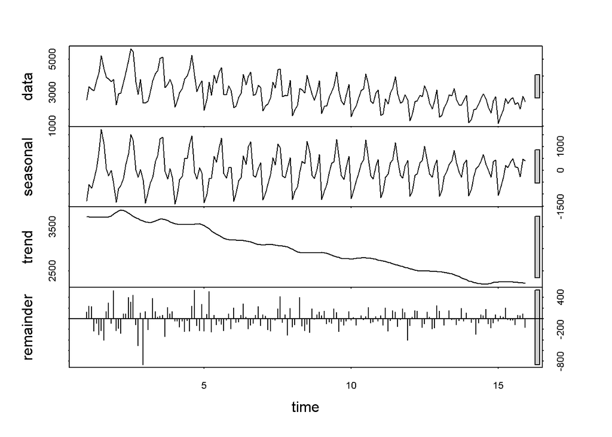

```r
fort_stl<-stl(fort,s.degree=1,s.window=7,t.degree=1,t.window=18,l.degree=1, l.window=7)

plot(fort_stl)
```

Нарисум тренд на фоне ряда.

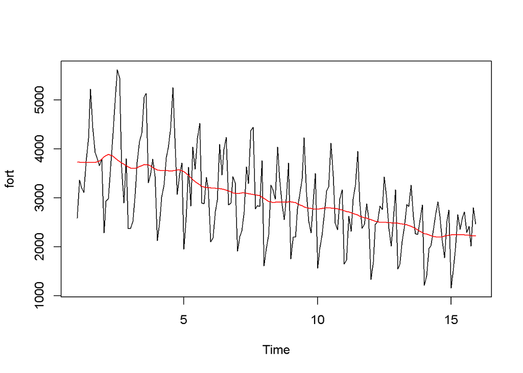

```r
stl_trend<-fort_stl$time.series[,2]
plot(fort)
lines(stl_trend,col="red",type="l")
```

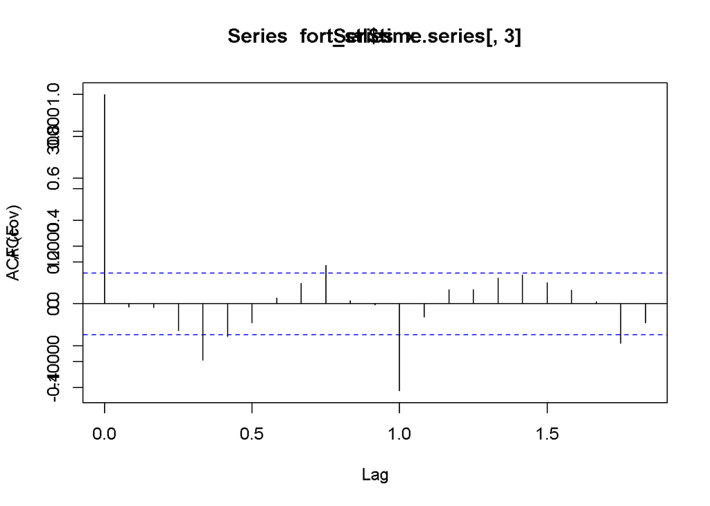

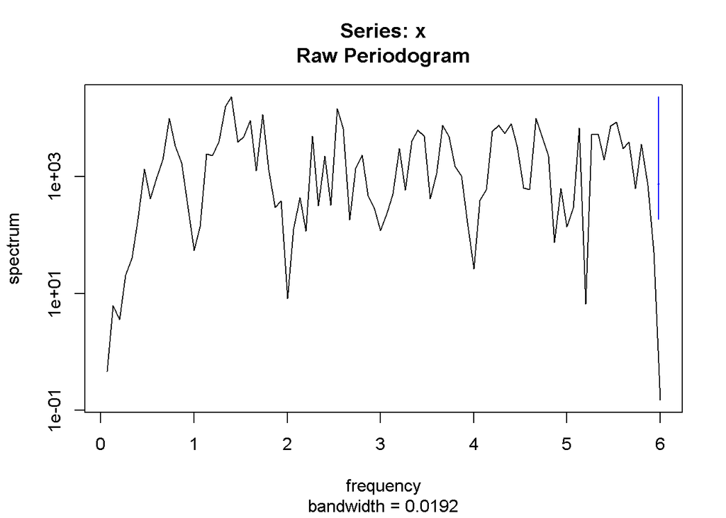

```
## [1] "no. of observations"
## [1] 180
## [1] "T"
## [1] 90
## [1] "CVM stat MN"
## [1] -0.9805472
## [1] "tMN"
## [1] -18.78912
## [1] "test value"
## [1] 0
```

```r
acf(fort_stl$time.series[,3])
 par(new=TRUE)
whitenoise.test(fort_stl$time.series[,3])
```

Тренд более гладкий, но в шуме, на мой взгляд, есть небольшая периодичность судя по автокорреляции.

## 3.2 SSA

Выделим тренд, будем использовать длину окна кратно периоду.Возьмем длину окна - число нацело делящееся на период + ближайшее к половине длины ряда.

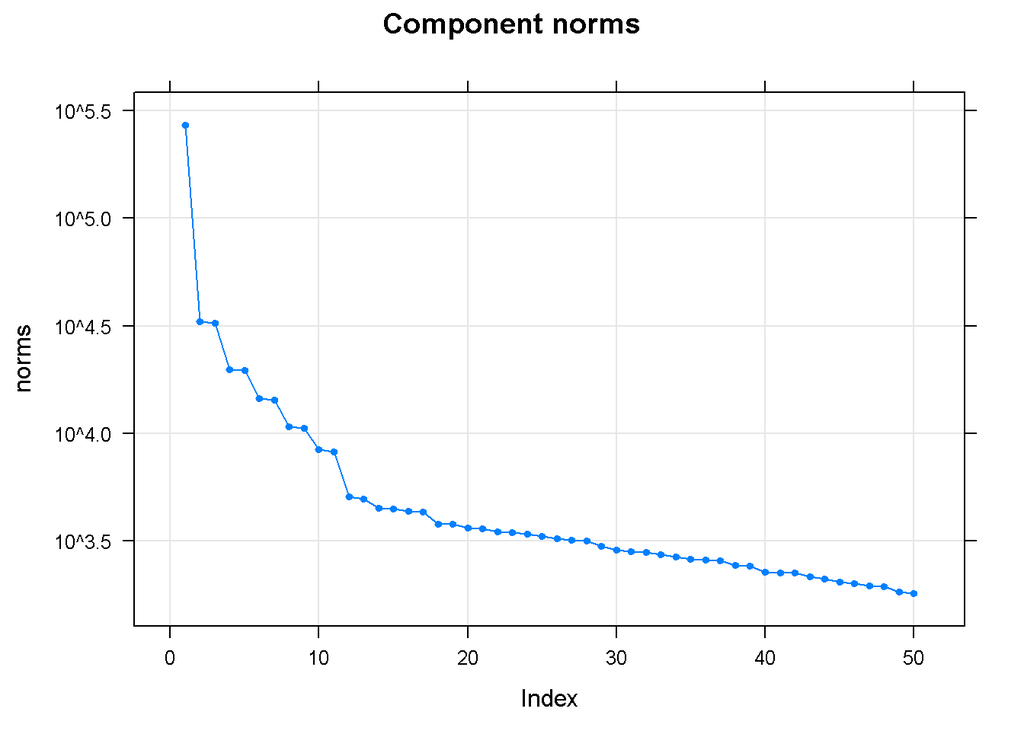

```r
ssa_fort <- ssa(fort, L = 84)
plot(ssa_fort)
```

Четко проссматриваются 5 ступенечек - 5 пар собственных чисел. Также предполагаем, что для тренда выделена одна компонента. 2-3,4-5,6-7,8-9,10-11 - гармоники.

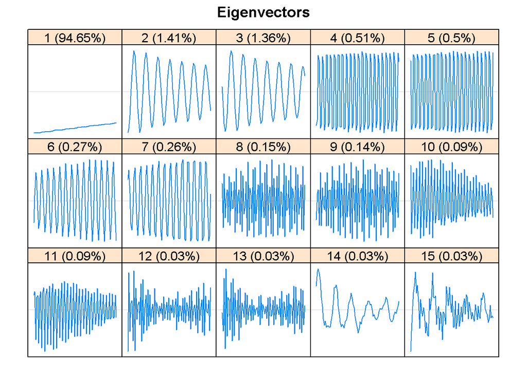

```r
#Рассмотрим графики одной переменной
plot(ssa_fort, type = "vectors", idx = 1:15)
```

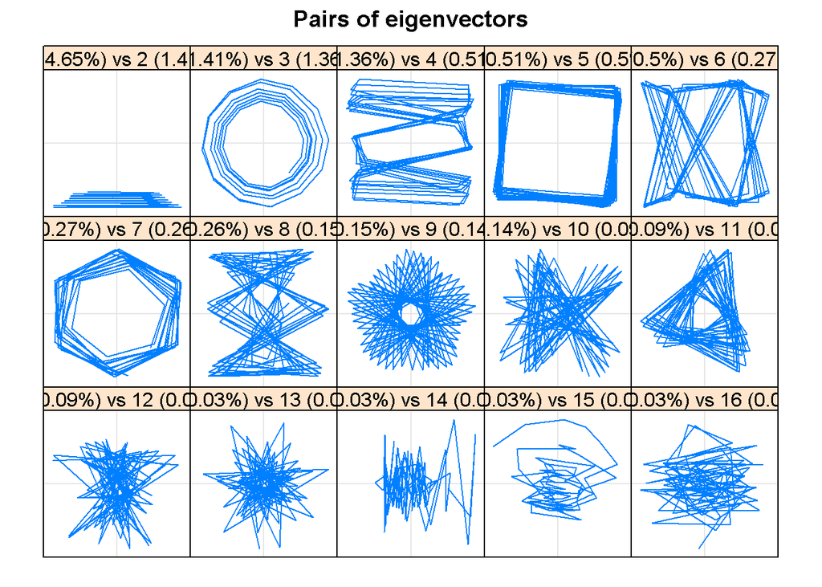

```r
#Рассмотрим парные графики
plot(ssa_fort,  type = "paired", idx = 1:15)
```

```r
#Видим, что все периоды видны, значит необходимость в последовательном SSA нет.
```

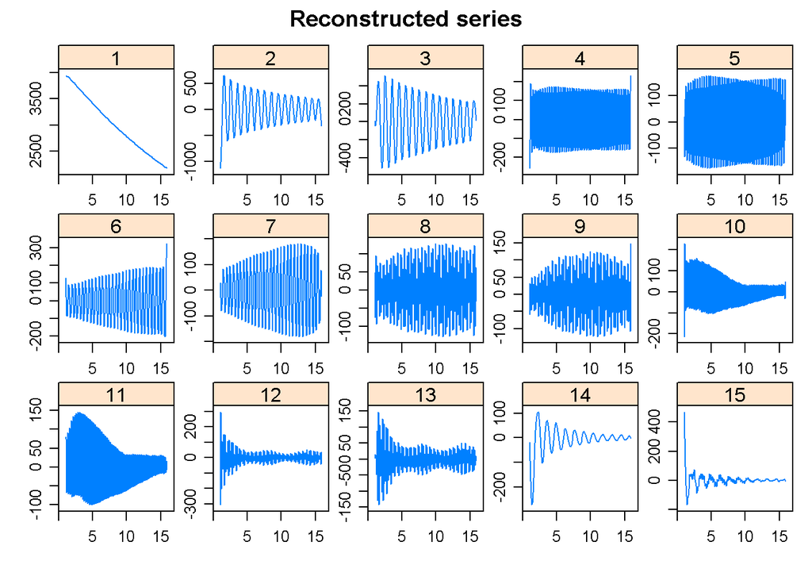

```r
plot(ssa_fort, type = "series", groups = as.list(1:15))
```

К тренду отнесем только первую компаненту как медленно меняющуюся.  
Корреляционная матрица

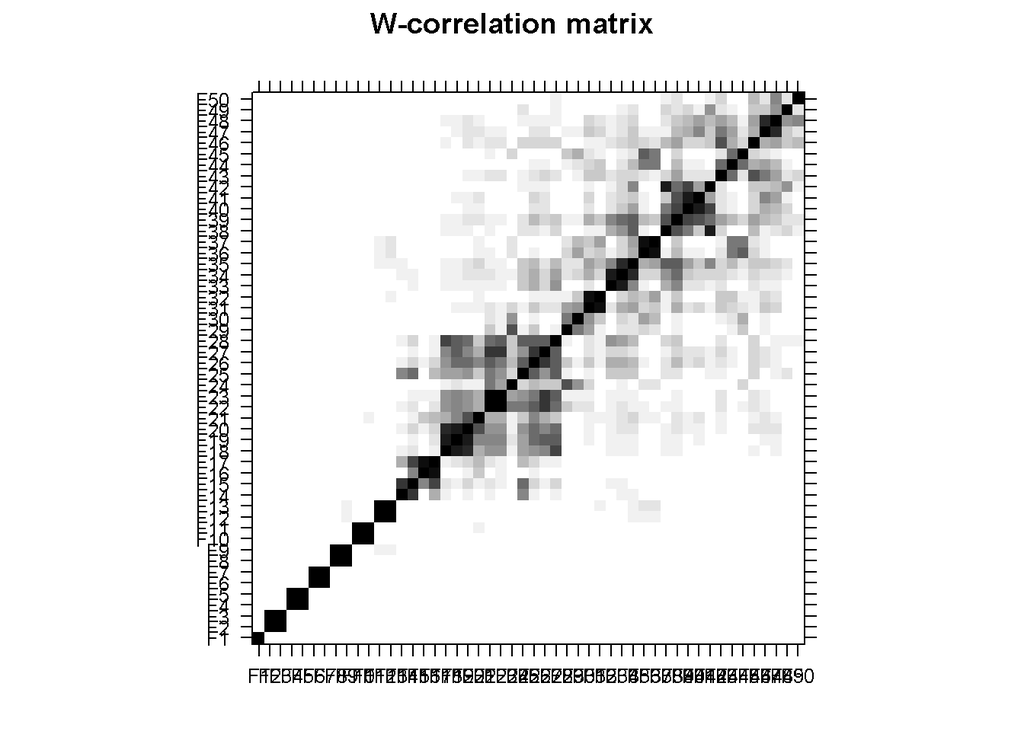

```r
plot(wcor(ssa_fort))
```

Видим, что 1, 2-3, 4-5, 6-7, 8-9 отделились хорошо, дальше началось смешивание 10-12 и дальше начинает шуметь.

```r
pe <- parestimate(ssa_fort, groups = list(2:11), method = "esprit")
pe
```

```
##    period     rate   |    Mod     Arg  |     Re        Im
##     5.967   0.003330 |  1.00334   1.05 |  0.49668   0.87178
##    -5.967   0.003330 |  1.00334  -1.05 |  0.49668  -0.87178
##     2.389   0.001557 |  1.00156   2.63 | -0.87331   0.49036
##    -2.389   0.001557 |  1.00156  -2.63 | -0.87331  -0.49036
##     3.998  -0.000031 |  0.99997   1.57 | -0.00074   0.99997
##    -3.998  -0.000031 |  0.99997  -1.57 | -0.00074  -0.99997
##    12.003  -0.005622 |  0.99439   0.52 |  0.86123   0.49710
##   -12.003  -0.005622 |  0.99439  -0.52 |  0.86123  -0.49710
##     3.014  -0.010143 |  0.98991   2.08 | -0.48679   0.86195
##    -3.014  -0.010143 |  0.98991  -2.08 | -0.48679  -0.86195
```

Периоды 6,4,3,12 и 2,4=12/5 описываются хорошо. Выделим тренд и сезонность и посмотрим на шум. Здесь возникают проблемы. Так как модель у нас мультипликативная, то шум нестанционарный (а белый шум предполагает независимость и одинаковое распределение)

## 3.3 Группировка

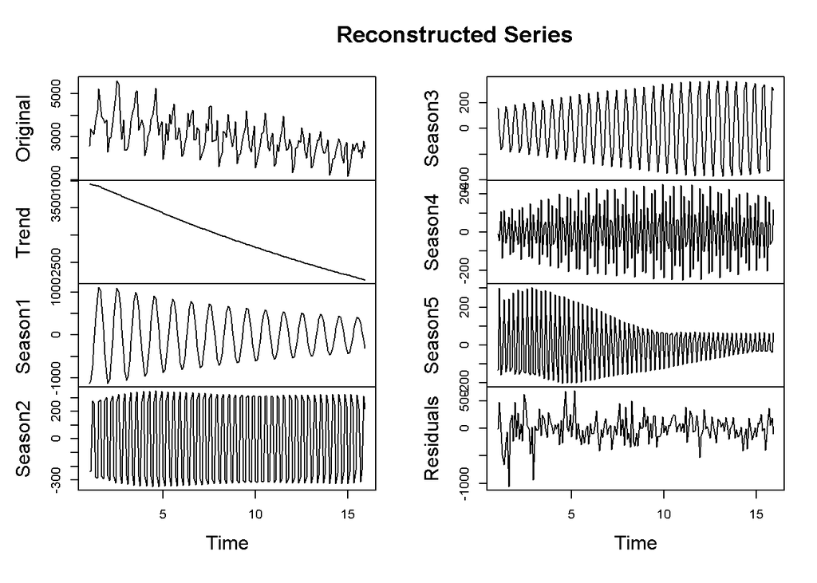

```r
#медленно меняющиеся 1,2

library(normwhn.test)
r <- reconstruct(ssa_fort, groups = list(Trend = c(1), Season1 = c(2,3), Season2 = c(4, 5),Season3 = c(6, 7), Season4 = c(8, 9), Season5 = c(10, 11)))
#r <- reconstruct(ssa_fort, groups = list(1,c(2,3), c(4, 5),c(6, 7), c(8, 9),  c(10, 11)))
res<-residuals(r)#jостаток
plot(r)
```

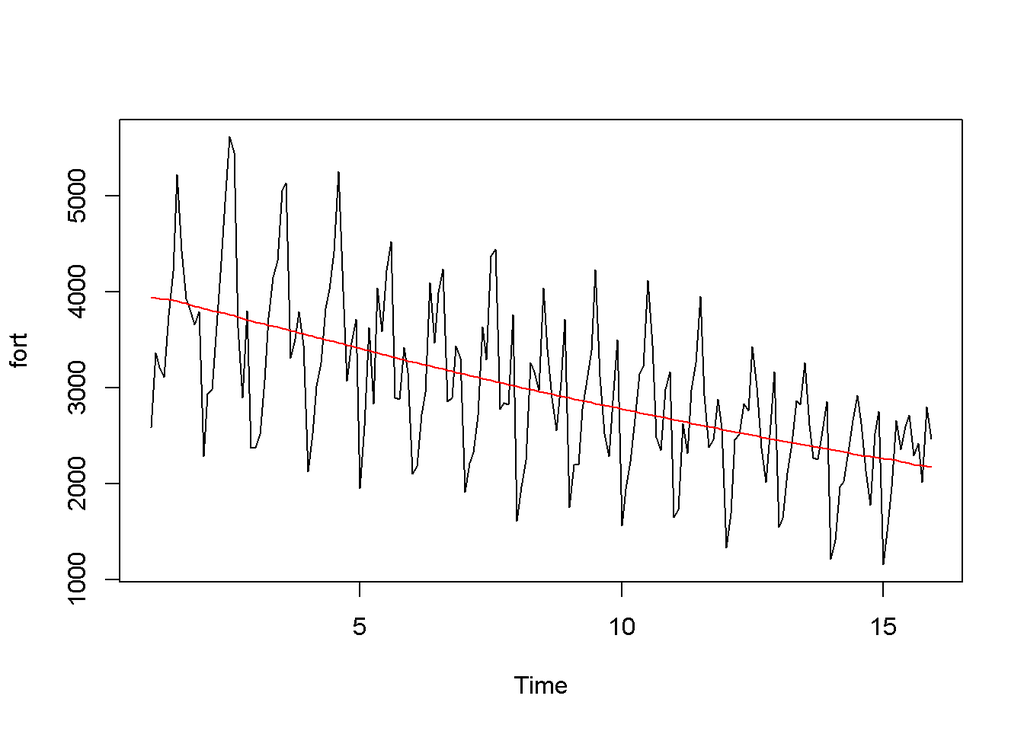

```r
plot(fort)
lines(r$Trend, col="red")
```

Мне кажется, что в данном случае тренд слишком гладкий.

Рассмотрим шум

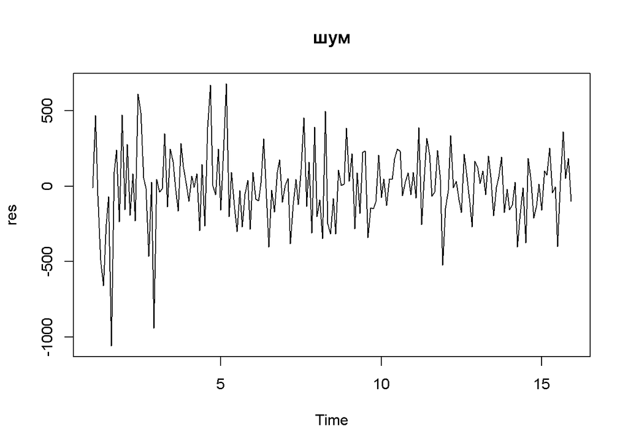

```r
plot(res, main="шум",type="l")
```

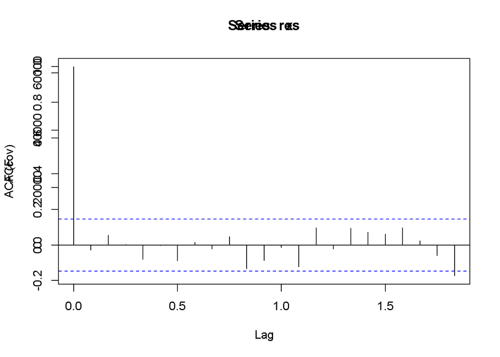

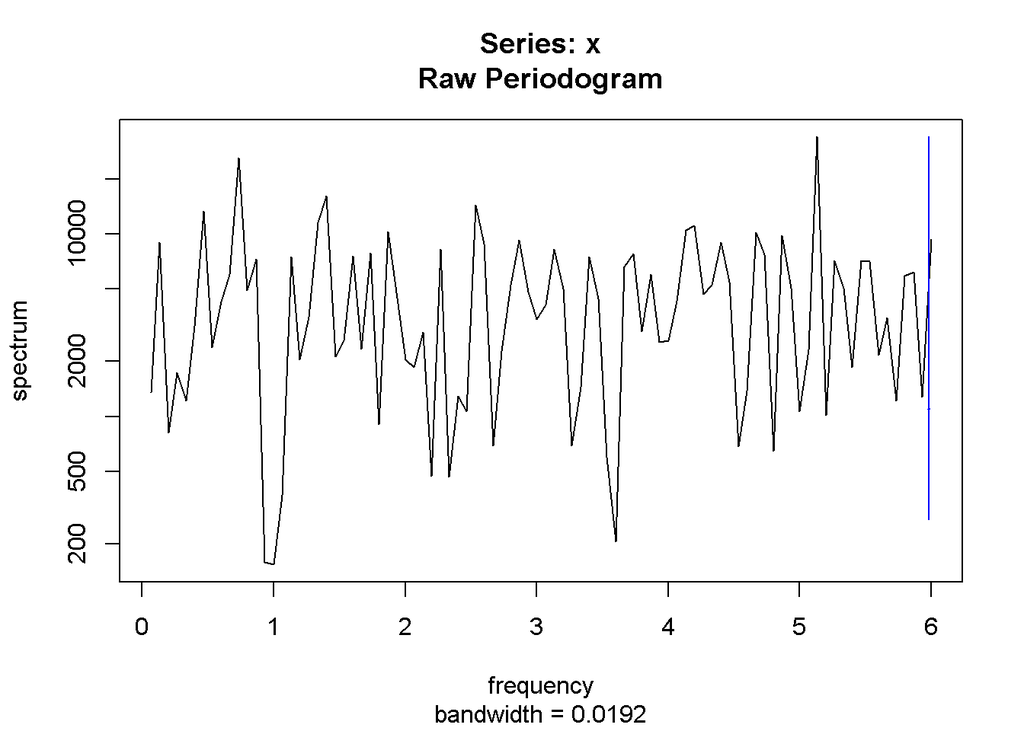

```
## [1] "no. of observations"
## [1] 180
## [1] "T"
## [1] 90
## [1] "CVM stat MN"
## [1] -0.9858804
## [1] "tMN"
## [1] -18.83972
## [1] "test value"
## [1] 0
```

```r
acf(res)
par(new=TRUE)
whitenoise.test(res)
```

Видим и по acf и по p value - что шум у нас не является белым.

## 3.4 Оценка дисперсии шума

Построим огибающие кривые для шума.

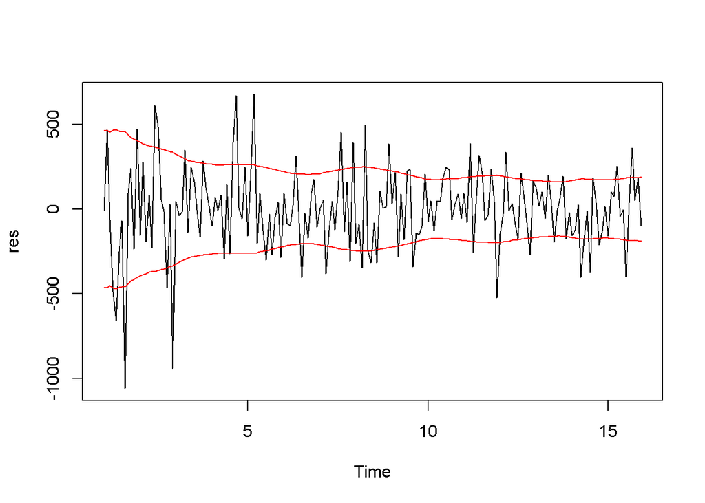

```r
restrend <- reconstruct(ssa(res**2, L = 21), groups = list(1))$F1
restrend <- sqrt(restrend)
plot(res, type='l')
lines(restrend, type='l', col="red")
lines(-restrend, type='l', col="red")
```

## 3.5 Тренды

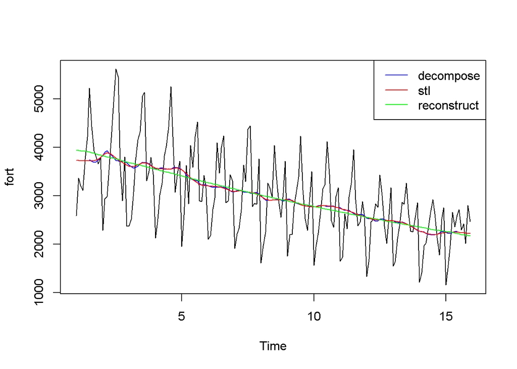

```r
plot(fort,col="black")
lines(fort_d$trend,col="blue")#decompose
lines(stl_trend,col="red")#Stl
lines(r$Trend,col="green")
legend("topright", legend = c("decompose", "stl","reconstruct"), col = c("blue","red","green"), lty = 1)
```